# Urban Growth Modeling Forecast - Orlando MSA

Projected Development Patterns for 2031

Author

Coco Zhou, Veronica Zheng

Published

April 29, 2026

# 1. Introduction & Planning Context

The Orlando-Kissimmee-Sanford Metropolitan Statistical Area is one of the most consequential growth stories in American urbanism. Spanning four counties across Central Florida, the region grew from about 2.1 million residents in 2010 to roughly 2.7 million by 2020, with continued population growth expected in coming decades. This growth is not occurring evenly – it radiates outward along Orlando’s fast-growing interstate and arterial network, converting wetlands, pine flatwoods, pasture, and agricultural land at a rate that poses significant environmental and infrastructure challenges.

This analysis adapts the Houston urban growth modeling workflow to the Orlando MSA. We construct a **binary spatial forecast model** that predicts land cover conversion from undeveloped to developed across the Orlando MSA between 2021 and 2031, using land cover, population, highway accessibility, county fixed effects, and spatial lag of existing development.

The model follows the reduced-form approach developed by Prof. John Landis and adapted here by Fichman and Steif: a binary logistic regression trained on observed 2011-2021 land cover change, with features drawn from land cover type, highway proximity, spatial lag of existing development, population density, and county fixed effects.

# 2. Setup

# 3. Study Area

The four-county Orlando MSA is loaded from the Census via `tigris` and projected to EPSG:5070 (NAD83 Conus Albers) - the native CRS of NLCD rasters, which eliminates reprojection errors during spatial aggregation.

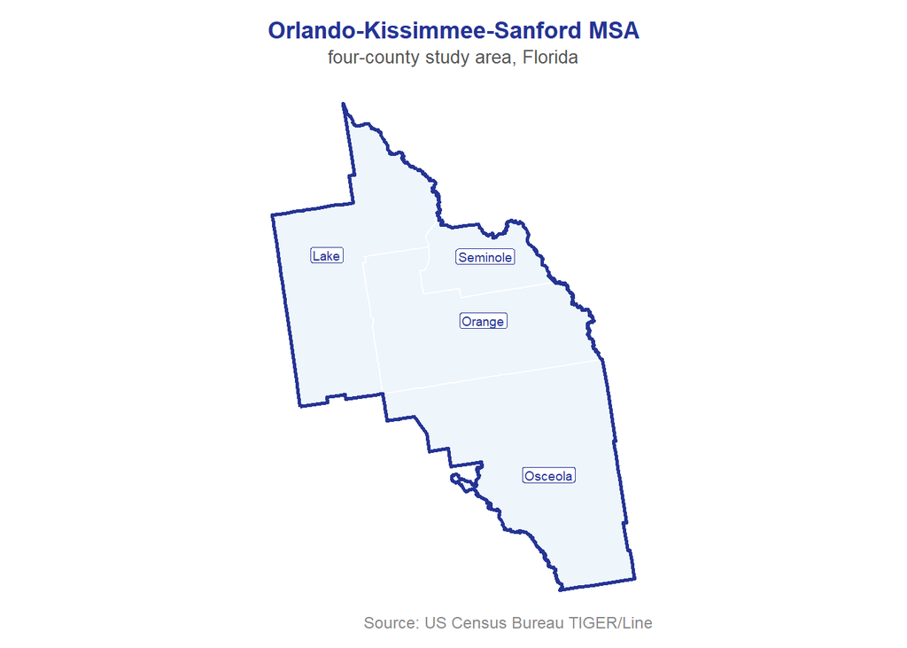

# 4. Land Cover Data

## 4.1. Load Local NLCD Rasters

We use local NLCD 2011 (t1) and NLCD 2021 (t2) land cover rasters from the `data/` folder, cropped to the Orlando MSA. The native 30m resolution is aggregated by a factor of 30 (~900m cells) to produce a manageable fishnet for modeling.

## 4.2. Resampling Rasters

Following the Houston model, the 30m NLCD rasters are aggregated by a factor of 30 to create coarser cells that are manageable for fishnet processing and modeling. Because land cover is categorical, the modal value is used during aggregation.

## 4.3. Reclassifying As Developed and Undeveloped

NLCD classes 21-24 are reclassified as “developed”; all other classes are treated as undeveloped for the binary change outcome. Map algebra identifies cells that were undeveloped in 2011 but developed in 2021 - these are our outcome of interest (value = 1).

The value `1` represents conversion from undeveloped to developed. Values of `0` and `2` are then set to `NA`, leaving only observed development change cells.

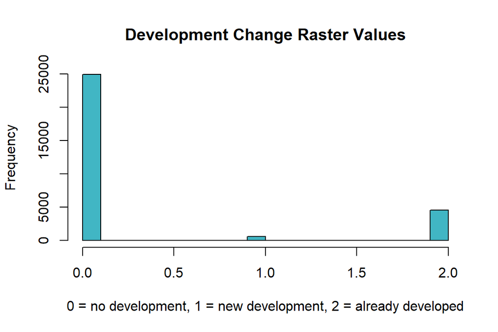

## 4.4. Examining Land Cover Change

The Houston workflow uses `mapView()` for a quick interactive check of the change raster. This gives a fast sanity check before joining change to the fishnet.

[interactive chart not shown]

## 4.5. Land Cover Type Variables

We recode NLCD classes into six reduced categories used as model predictors.

# 5. Fishnet Construction

We construct a vector fishnet at the resampled raster resolution, clipped to the MSA boundary. Each cell becomes a row in our modeling dataset.

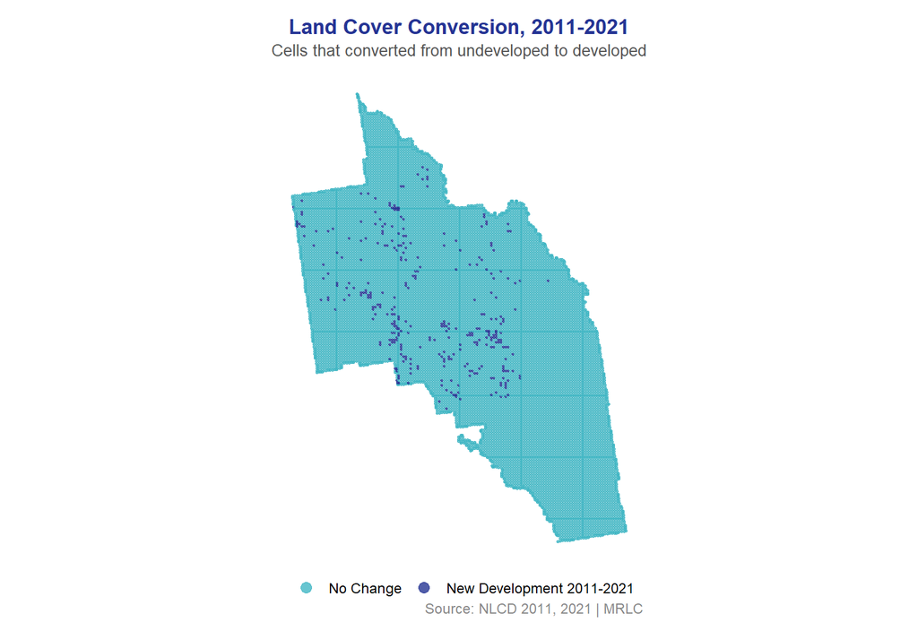

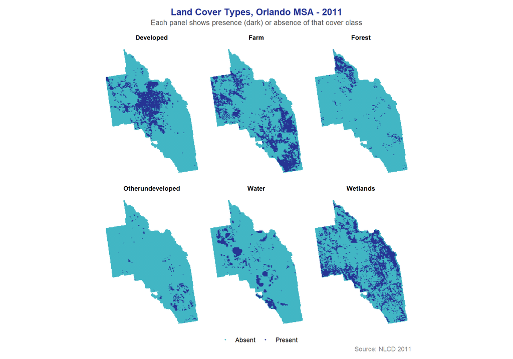

# 6. Predictor Variables

## 6.1. Population Density

Population data from the 5-year ACS at the tract level is interpolated to the fishnet using areal weighted interpolation, which apportions each tract’s population to intersecting cells proportional to the share of area they cover.

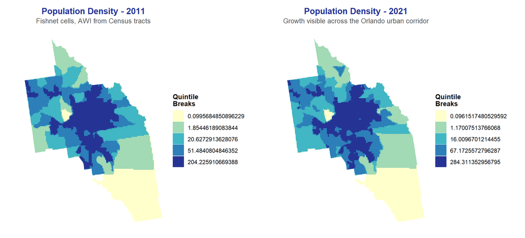

# 7. Transportation And Infrastructure

Accessibility is a key determinant of development potential. Following the Houston model, this Orlando version uses highway accessibility as the transportation feature. The hypothesis is that cells closer to major road infrastructure are more likely to convert to developed land.

This version does **not** use the station, rail, or infrastructure-scenario features from the earlier Orlando report. It keeps the transportation workflow aligned with the Houston model: download primary/secondary roads, calculate distance to highways, and use that distance in the final logistic model.

## 7.1. Download Highways

Primary and secondary roads are downloaded from `tigris`, projected, and clipped to the Orlando MSA.

Let’s make a map and examine the spatial relationship between highways and development change.

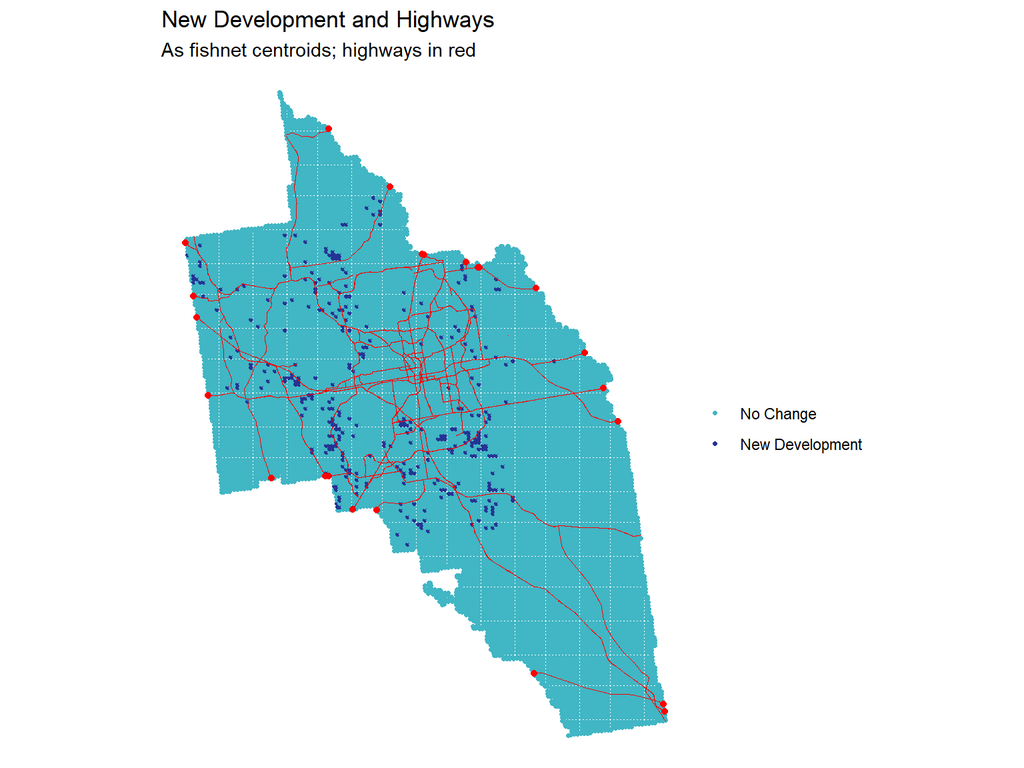

## 7.2. Calculate Distance to Highways

This step creates the `distance_highways_2011` feature by calculating distance from each fishnet centroid to the nearest highway segment. As in the Houston model, the t2 transportation network is assumed to be the same as t1, so the 2021 highway-distance fishnet is a renamed copy of the 2011 highway-distance fishnet.

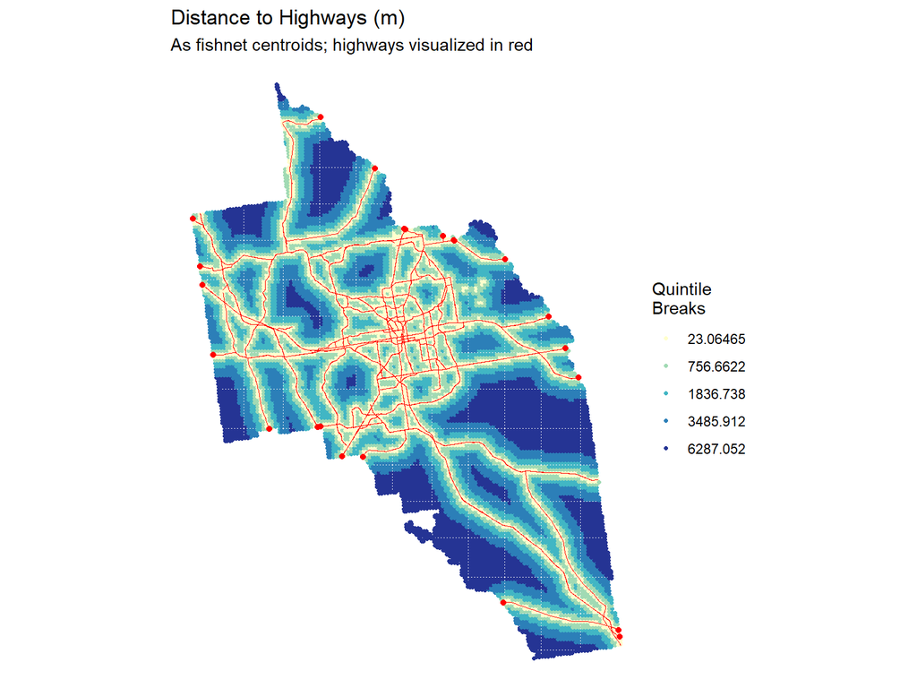

# 8. Spatial Lag of Development

The average distance from each fishnet cell to its two nearest developed cells - a spatial endogeneity feature capturing the “leapfrog” or “infill” nature of surrounding development patterns.

# 9. County Fixed Effects

# 10. Modeling Dataset Assembly

We combine all fishnet layers into modeling datasets. `rename_with` strips year suffixes so the model (trained on t1 names) can accept t2 data for forecasting.

# 11. Feature Exploration

The bar plots below mirror the Houston report’s feature exploration. They compare the mean value of each continuous predictor for cells that changed versus cells that did not change.

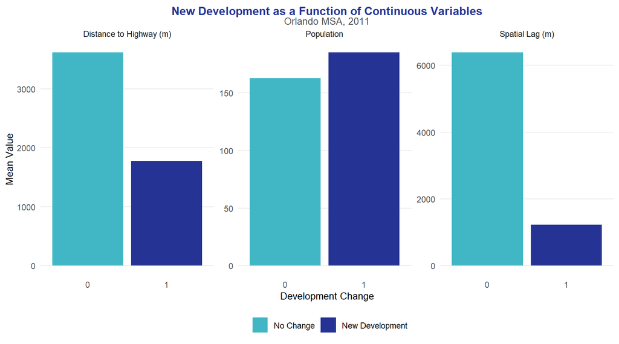

Proportion of converted cells by 2011 land cover type

| Land Cover Type | Share of Converted Cells |
| --- | --- |
| farm | 2.11% |
| forest | 0.34% |
| otherUndeveloped | 0.06% |
| wetlands | 0.8% |

# 12. Modeling

## 12.1. Train / Test Split

## 12.2. Model Specifications

Six models of increasing complexity, matching the Houston specification. Model 6 interacts spatial lag with highway distance.

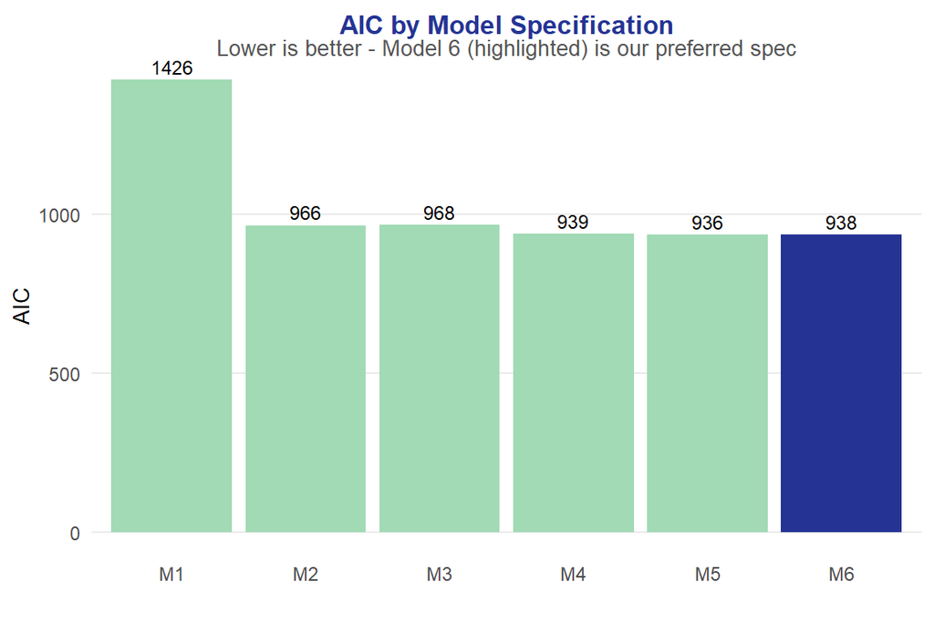

## 12.3. Model 6 Summary

```
Call:
glm(formula = development_change ~ wetlands + forest + farm +
    otherUndeveloped + pop + lagDevelopment * distance_highways +
    NAME, family = binomial(link = "logit"), data = datTrain)

Coefficients:
                                   Estimate Std. Error z value Pr(>|z|)
(Intercept)                      -4.603e+00  5.235e-01  -8.793  < 2e-16 ***
wetlands1                         3.798e+00  4.483e-01   8.472  < 2e-16 ***
forest1                           4.709e+00  5.335e-01   8.827  < 2e-16 ***
farm1                             5.640e+00  4.613e-01  12.226  < 2e-16 ***
otherUndeveloped1                 5.405e+00  7.873e-01   6.865 6.66e-12 ***
pop                              -6.750e-04  4.526e-04  -1.491 0.135849
lagDevelopment                   -1.921e-03  2.710e-04  -7.088 1.36e-12 ***
distance_highways                -1.635e-04  1.179e-04  -1.386 0.165659
NAMEOrange                        1.230e+00  2.324e-01   5.291 1.21e-07 ***
NAMEOsceola                       9.430e-01  2.531e-01   3.725 0.000195 ***
NAMESeminole                      1.574e-01  4.037e-01   0.390 0.696657
lagDevelopment:distance_highways  4.559e-08  7.753e-08   0.588 0.556545
---
Signif. codes:  0 '***' 0.001 '**' 0.01 '*' 0.05 '.' 0.1 ' ' 1

(Dispersion parameter for binomial family taken to be 1)

    Null deviance: 1509.06  on 5959  degrees of freedom
Residual deviance:  913.91  on 5948  degrees of freedom
AIC: 937.91

Number of Fisher Scoring iterations: 13
```

## 12.4. Validation

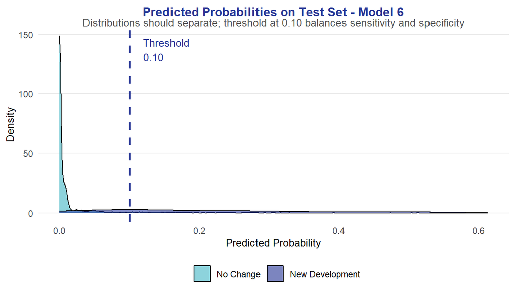

```
Confusion Matrix and Statistics

          Reference
Prediction    0    1
         0 5405   48
         1  403  102

               Accuracy : 0.9243
                 95% CI : (0.9173, 0.9309)
    No Information Rate : 0.9748
    P-Value [Acc > NIR] : 1

                  Kappa : 0.2836

 Mcnemar's Test P-Value : <2e-16

            Sensitivity : 0.68000
            Specificity : 0.93061
         Pos Pred Value : 0.20198
         Neg Pred Value : 0.99120
             Prevalence : 0.02518
         Detection Rate : 0.01712
   Detection Prevalence : 0.08476
      Balanced Accuracy : 0.80531

       'Positive' Class : 1
```

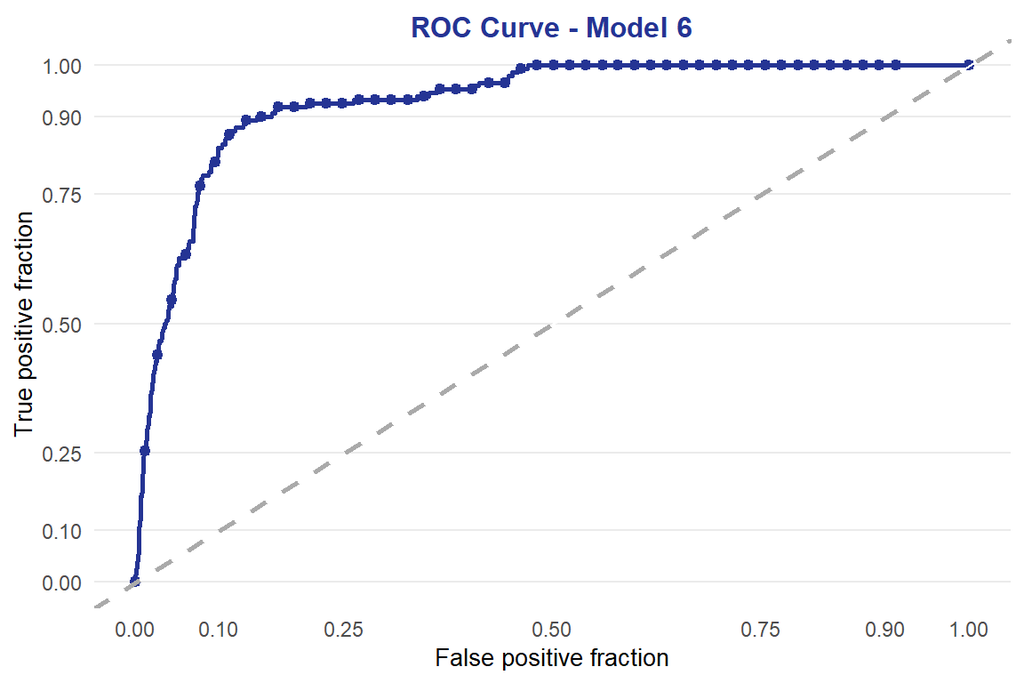

## 12.5. Spatial Error Analysis

Model sensitivity and specificity by county and threshold

| County | Threshold | Sensitivity | Specificity |
| --- | --- | --- | --- |
| Lake | 10% Threshold | 64.5 | 92.5 |
| Lake | 5% Threshold | 77.4 | 86.9 |
| Orange | 10% Threshold | 80.2 | 86.6 |
| Orange | 5% Threshold | 92.1 | 81.4 |
| Osceola | 10% Threshold | 79.5 | 96.1 |
| Osceola | 5% Threshold | 89.7 | 93.7 |
| Seminole | 10% Threshold | 27.8 | 97.4 |
| Seminole | 5% Threshold | 55.6 | 91.1 |

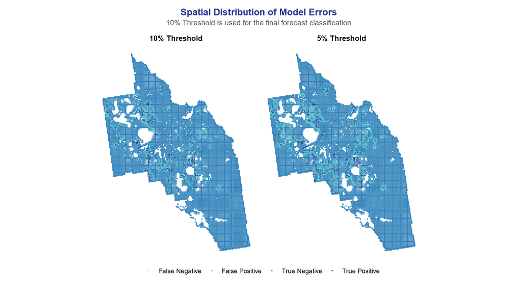

# 13. Forecast 2031

Following the Houston workflow, we use the preferred logistic regression model (`Model6`) and the t2 predictor set (`dat_2021`) to forecast likely development by 2031. The classification threshold is 0.10, matching the validation section above.

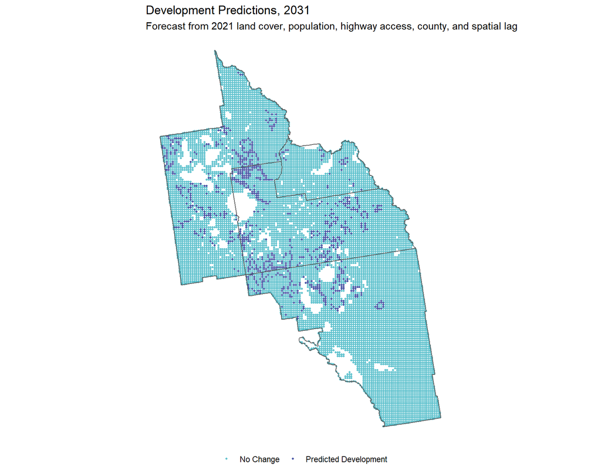

# 14. Impact Assessment

How much land is anticipated to convert by 2031? The tables below summarize the forecast in three ways: total conversion across the Orlando MSA, conversion by county, and sensitive land expected to convert by county and land cover type.

## 14.1. Total Forecasted Conversion

Total forecasted land conversion by 2031

| NAME | total_cells | total_area_m | total_km2 | total_mi2 |
| --- | --- | --- | --- | --- |
| Orlando MSA Total | 915 | 741150000 | 741.15 | 286.1595 |

## 14.2. Forecast by County

Forecast by county, 2031

| NAME | total_cells | total_area_m | total_km2 | total_mi2 |
| --- | --- | --- | --- | --- |
| Orange | 396 | 320760000 | 320.76 | 123.846078 |
| Lake | 290 | 234900000 | 234.90 | 90.695360 |
| Osceola | 198 | 160380000 | 160.38 | 61.923039 |
| Seminole | 31 | 25110000 | 25.11 | 9.695021 |

## 14.3. Sensitive Land Expected to Convert

Forecast by `t2` land cover type:

Forecast by t2 land cover type, 2031

| NAME | Variable | total_cells | total_area_m | total_km2 | total_mi2 |
| --- | --- | --- | --- | --- | --- |
| Lake | farm | 252 | 204120000 | 204.12 | 78.811140 |
| Lake | forest | 32 | 25920000 | 25.92 | 10.007764 |
| Lake | otherUndeveloped | 6 | 4860000 | 4.86 | 1.876456 |
| Lake | wetlands | 0 | 0 | 0.00 | 0.000000 |
| Orange | farm | 129 | 104490000 | 104.49 | 40.343798 |
| Orange | forest | 43 | 34830000 | 34.83 | 13.447933 |
| Orange | otherUndeveloped | 8 | 6480000 | 6.48 | 2.501941 |
| Orange | wetlands | 216 | 174960000 | 174.96 | 67.552406 |
| Osceola | farm | 107 | 86670000 | 86.67 | 33.463460 |
| Osceola | forest | 7 | 5670000 | 5.67 | 2.189198 |
| Osceola | otherUndeveloped | 0 | 0 | 0.00 | 0.000000 |
| Osceola | wetlands | 84 | 68040000 | 68.04 | 26.270380 |
| Seminole | farm | 20 | 16200000 | 16.20 | 6.254852 |
| Seminole | forest | 11 | 8910000 | 8.91 | 3.440169 |
| Seminole | otherUndeveloped | 0 | 0 | 0.00 | 0.000000 |
| Seminole | wetlands | 0 | 0 | 0.00 | 0.000000 |

# 15. Planning Recommendations

**Recommendation 1 - Protect Wetlands and Floodplain Buffers.** The forecast identifies likely development pressure in a region where wetlands and floodplain systems shape both ecological function and hazard exposure. MetroPlan Orlando and member counties should prioritize conservation easements, transfer-of-development-rights programs, and acquisition partnerships in forecasted growth areas that overlap wetlands and floodplain buffers.

**Recommendation 2 - Coordinate Highway-Accessible Growth Centers.** Because the Houston-style model uses highway access as the transportation feature, predicted growth should be interpreted as pressure around the region’s major road network. Counties should use targeted zoning overlays and infrastructure phasing to steer this demand toward compact centers rather than scattered highway-adjacent conversion.

**Recommendation 3 - Tie Infrastructure Funding to Forecasted County Impacts.** County-level forecast outputs can help identify where roads, utilities, schools, and conservation investments will face the greatest pressure. A regional impact fee or interlocal funding agreement could direct a share of development value toward the places absorbing the largest forecasted service burdens.